# 03-exercises

Emmeline Tsen

April 20, 2016

## Readings

*APM*

- Chapter 4 “Over Fitting and Model Tuning”
- Chapter 12.2 “Logisitic Regression”"

## Miscellaneous

I am still struggling with names …

- Please send me your picture

## Assignment

Note: The following will set-up your environment for this exercise. If you get an error stating that the packages have not been found, you need to install those packages.

## StepAIC

Using Fuel Economy data set from the **AppliedPredictiveModeling** Package. - fit the simplest possible model using lm - Use MASS::StepAIC to improve the model using forward stepwise regression - Fit the “full” model using lm - USe MASS::StepAIC to improve the model using backward stepwise regression

```r
#simplest model using fuel economy. using 1 would give you an intercept
  fit.min <- lm(FE ~ 1, fe) #also the mean fe$FE %>% mean

  # stepAIC(fit.min, scope= ~1 + EngDispl + NumCyl, direction = "forward")
  # went through 3 steps.
  # look at the things that it can add to it (EngDisp + NumCyl).
  # EngDisp lowers the AIC (lowers it the most)
  # then it can either add NumCyl or nothing. NumCyl lowers the AIC so it goes to NumCyl

 # stepAIC(fit.min, scope= ~1 + EngDispl + NumCyl + Transmission, direction = "forward")

 # stepAIC (fit.min, scope = ~., direction = "forward")

  fe %>% names %>% cat (sep=" +")
```

```
## EngDispl +NumCyl +Transmission +FE +AirAspirationMethod +NumGears +TransLockup +TransCreeperGear +DriveDesc +IntakeValvePerCyl +ExhaustValvesPerCyl +CarlineClassDesc +VarValveTiming +VarValveLift
```

```r
  form <- ~EngDispl +NumCyl +Transmission +FE +AirAspirationMethod +NumGears +TransLockup +TransCreeperGear +DriveDesc +IntakeValvePerCyl +ExhaustValvesPerCyl +CarlineClassDesc +VarValveTiming +VarValveLift

  fit.min.forward <- stepAIC (fit.min, scope = form, direction = "forward")
```

```
## Start:  AIC=6054.49
## FE ~ 1
```

```
##                       Df Sum of Sq   RSS    AIC
## + EngDispl             1     60851 33997 4571.9
## + NumCyl               1     52979 41869 4873.2
## + DriveDesc            4     43848 51000 5164.7
## + CarlineClassDesc    16     32977 61871 5468.3
## + ExhaustValvesPerCyl  1     14745 80103 5812.0
## + Transmission        15     14786 80062 5839.3
## + IntakeValvePerCyl    1     11842 83006 5863.5
## + TransLockup          1      6707 88141 5950.4
## + NumGears             1      2761 92087 6013.7
## + VarValveLift         1      1874 92974 6027.6
## + VarValveTiming       1      1856 92993 6027.9
## + AirAspirationMethod  2      1402 93446 6036.9
## + TransCreeperGear     1      1121 93727 6039.3
## <none>                             94848 6054.5
##
## Step:  AIC=4571.86
## FE ~ EngDispl
```

```
##                       Df Sum of Sq   RSS    AIC
## + CarlineClassDesc    16    8649.4 25348 4179.0
## + DriveDesc            4    7403.9 26593 4224.4
## + Transmission        15    2403.8 31593 4495.7
## + TransLockup          1     633.4 33364 4546.6
## + VarValveTiming       1     525.3 33472 4551.3
## + TransCreeperGear     1     250.2 33747 4563.2
## + NumCyl               1     230.6 33766 4564.0
## + VarValveLift         1     172.2 33825 4566.5
## + AirAspirationMethod  2     166.4 33831 4568.8
## + IntakeValvePerCyl    1      88.9 33908 4570.1
## + ExhaustValvesPerCyl  1      55.6 33941 4571.5
## <none>                             33997 4571.9
## + NumGears             1      28.8 33968 4572.6
##
## Step:  AIC=4179.04
## FE ~ EngDispl + CarlineClassDesc
```

```
##                       Df Sum of Sq   RSS    AIC
## + DriveDesc            4    4302.0 21046 3917.9
## + Transmission        15    2648.2 22699 4049.4
## + NumCyl               1    1862.9 23485 4070.6
## + IntakeValvePerCyl    1     999.2 24348 4122.8
## + ExhaustValvesPerCyl  1     788.1 24560 4135.3
## + AirAspirationMethod  2     697.7 24650 4142.6
## + NumGears             1     602.0 24746 4146.3
## + TransLockup          1     142.8 25205 4172.9
## + VarValveTiming       1      64.2 25283 4177.4
## <none>                             25348 4179.0
## + TransCreeperGear     1      30.9 25317 4179.3
## + VarValveLift         1      18.7 25329 4180.0
##
## Step:  AIC=3917.9
## FE ~ EngDispl + CarlineClassDesc + DriveDesc
```

```
##                       Df Sum of Sq   RSS    AIC
## + Transmission        15   2059.69 18986 3798.9
## + NumCyl               1   1320.61 19725 3826.1
## + IntakeValvePerCyl    1    647.48 20398 3874.7
## + ExhaustValvesPerCyl  1    471.61 20574 3887.1
## + VarValveLift         1    241.63 20804 3903.2
## + NumGears             1    166.46 20879 3908.4
## + AirAspirationMethod  2    148.50 20897 3911.7
## + TransLockup          1    100.65 20945 3913.0
## + TransCreeperGear     1     45.76 21000 3916.8
## + VarValveTiming       1     44.34 21001 3916.9
## <none>                             21046 3917.9
##
## Step:  AIC=3798.87
## FE ~ EngDispl + CarlineClassDesc + DriveDesc + Transmission
```

```
##                       Df Sum of Sq   RSS    AIC
## + NumCyl               1   1217.12 17769 3705.0
## + IntakeValvePerCyl    1    701.50 18284 3746.4
## + ExhaustValvesPerCyl  1    472.32 18514 3764.4
## + VarValveLift         1    283.63 18702 3779.1
## + AirAspirationMethod  2    115.12 18871 3794.1
## + NumGears             1     81.25 18905 3794.7
## + TransLockup          1     81.00 18905 3794.7
## + TransCreeperGear     1     40.47 18945 3797.8
## <none>                             18986 3798.9
## + VarValveTiming       1      0.82 18985 3800.8
##
## Step:  AIC=3705
## FE ~ EngDispl + CarlineClassDesc + DriveDesc + Transmission +
##     NumCyl
```

```
##                       Df Sum of Sq   RSS    AIC
## + IntakeValvePerCyl    1   289.127 17480 3683.3
## + ExhaustValvesPerCyl  1   261.463 17507 3685.6
## + VarValveLift         1   191.161 17578 3691.4
## + NumGears             1    63.769 17705 3701.8
## + TransLockup          1    55.834 17713 3702.4
## + AirAspirationMethod  2    67.243 17702 3703.5
## <none>                             17769 3705.0
## + TransCreeperGear     1    16.668 17752 3705.6
## + VarValveTiming       1     0.232 17768 3707.0
##
## Step:  AIC=3683.26
## FE ~ EngDispl + CarlineClassDesc + DriveDesc + Transmission +
##     NumCyl + IntakeValvePerCyl
```

```
##                       Df Sum of Sq   RSS    AIC
## + VarValveLift         1   207.431 17272 3668.0
## + AirAspirationMethod  2    78.398 17401 3680.8
## + TransLockup          1    51.921 17428 3681.0
## + NumGears             1    46.560 17433 3681.4
## <none>                             17480 3683.3
## + TransCreeperGear     1    17.890 17462 3683.8
## + VarValveTiming       1     8.873 17471 3684.5
## + ExhaustValvesPerCyl  1     7.561 17472 3684.6
##
## Step:  AIC=3667.99
## FE ~ EngDispl + CarlineClassDesc + DriveDesc + Transmission +
##     NumCyl + IntakeValvePerCyl + VarValveLift
```

```
##                       Df Sum of Sq   RSS    AIC
## + TransLockup          1    65.285 17207 3664.5
## + NumGears             1    42.190 17230 3666.5
## <none>                             17272 3668.0
## + AirAspirationMethod  2    41.235 17231 3668.5
## + TransCreeperGear     1    13.445 17259 3668.9
## + VarValveTiming       1     9.959 17262 3669.2
## + ExhaustValvesPerCyl  1     8.365 17264 3669.3
##
## Step:  AIC=3664.51
## FE ~ EngDispl + CarlineClassDesc + DriveDesc + Transmission +
##     NumCyl + IntakeValvePerCyl + VarValveLift + TransLockup
```

```
##                       Df Sum of Sq   RSS    AIC
## + NumGears             1    45.751 17161 3662.7
## + AirAspirationMethod  2    47.697 17159 3664.5
## <none>                             17207 3664.5
## + TransCreeperGear     1    13.832 17193 3665.3
## + VarValveTiming       1    10.861 17196 3665.6
## + ExhaustValvesPerCyl  1     8.766 17198 3665.8
##
## Step:  AIC=3662.66
## FE ~ EngDispl + CarlineClassDesc + DriveDesc + Transmission +
##     NumCyl + IntakeValvePerCyl + VarValveLift + TransLockup +
##     NumGears
```

```
##                       Df Sum of Sq   RSS    AIC
## <none>                             17161 3662.7
## + AirAspirationMethod  2    41.841 17119 3663.1
## + TransCreeperGear     1    14.106 17147 3663.5
## + VarValveTiming       1    10.960 17150 3663.7
## + ExhaustValvesPerCyl  1     7.542 17154 3664.0
```

```r
  summary(fit.min.forward)
```

```
##
## Call:
## lm(formula = FE ~ EngDispl + CarlineClassDesc + DriveDesc + Transmission +
##     NumCyl + IntakeValvePerCyl + VarValveLift + TransLockup +
##     NumGears, data = fe)
##
## Residuals:
##      Min       1Q   Median       3Q      Max
## -17.5487  -1.9801  -0.0859   1.8311  20.3907
##
## Coefficients:
##                                                 Estimate Std. Error
## (Intercept)                                      56.6568     2.2658
## EngDispl                                         -2.2864     0.2176
## CarlineClassDesc2Seaters                          3.8245     0.9839
## CarlineClassDescCompactCars                       4.5804     0.9200
## CarlineClassDescLargeCars                         3.4469     0.9580
## CarlineClassDescMidsizeCars                       4.3197     0.9250
## CarlineClassDescMinicompactCars                   4.1510     1.0213
## CarlineClassDescSmallPickupTrucks2WD             -1.2311     1.0949
## CarlineClassDescSmallPickupTrucks4WD             -0.2672     1.2216
## CarlineClassDescSmallStationWagons                2.8236     0.9683
## CarlineClassDescSpecialPurposeVehicleminivan2WD  -2.3289     1.1952
## CarlineClassDescSpecialPurposeVehicleSUV2WD      -1.0573     0.9364
## CarlineClassDescSpecialPurposeVehicleSUV4WD       0.4903     0.9465
## CarlineClassDescStandardPickupTrucks2WD          -0.4694     1.0862
## CarlineClassDescStandardPickupTrucks4WD          -0.9136     1.1176
## CarlineClassDescSubcompactCars                    3.9098     0.9386
## CarlineClassDescVansCargoTypes                   -3.3469     1.1973
## CarlineClassDescVansPassengerType                -4.5077     1.2517
## DriveDescFourWheelDrive                          -0.1221     0.4155
## DriveDescParttimeFourWheelDrive                   0.2736     1.1514
## DriveDescTwoWheelDriveFront                       5.6349     0.3496
## DriveDescTwoWheelDriveRear                        1.6137     0.3434
## TransmissionA4                                   -6.7371     1.2250
## TransmissionA5                                   -5.2937     1.1757
## TransmissionA6                                   -3.3368     1.2044
## TransmissionA7                                   -2.7830     1.3337
## TransmissionAM6                                  -5.4654     1.4496
## TransmissionAM7                                  -6.2919     1.7440
```

[output cut: 48 more lines]

```
## TransmissionS5                                   -5.633 2.13e-08 ***
## TransmissionS6                                   -3.727 0.000202 ***
## TransmissionS7                                   -3.011 0.002647 **
## TransmissionS8                                   -0.722 0.470113
## NumCyl                                           -7.574 6.54e-14 ***
## IntakeValvePerCyl                                -4.819 1.60e-06 ***
## VarValveLift                                      4.210 2.71e-05 ***
## TransLockup                                      -2.374 0.017724 *
## NumGears                                         -1.935 0.053144 .
## ---
## Signif. codes:  0 '***' 0.001 '**' 0.01 '*' 0.05 '.' 0.1 ' ' 1
##
## Residual standard error: 3.495 on 1405 degrees of freedom
## Multiple R-squared:  0.8191, Adjusted R-squared:  0.8138
## F-statistic: 155.1 on 41 and 1405 DF,  p-value: < 2.2e-16
```

```r
  fit.min.forward.backward <- stepAIC (fit.min.forward, scope = ~1, direction = "backward")  # to try to further reduce it. 1 meaning just the intercept
```

```
## Start:  AIC=3662.66
## FE ~ EngDispl + CarlineClassDesc + DriveDesc + Transmission +
##     NumCyl + IntakeValvePerCyl + VarValveLift + TransLockup +
##     NumGears
##
##                     Df Sum of Sq   RSS    AIC
## <none>                           17161 3662.7
## - NumGears           1      45.8 17207 3664.5
## - TransLockup        1      68.8 17230 3666.5
## - VarValveLift       1     216.5 17378 3678.8
## - IntakeValvePerCyl  1     283.7 17445 3684.4
## - NumCyl             1     700.6 17862 3718.6
## - EngDispl           1    1348.1 18509 3770.1
## - Transmission      15    2054.4 19216 3796.3
## - DriveDesc          4    3576.6 20738 3928.6
## - CarlineClassDesc  16    5236.6 22398 4016.0
```

```r
  summary (fit.min.forward.backward)
```

```
##
## Call:
## lm(formula = FE ~ EngDispl + CarlineClassDesc + DriveDesc + Transmission +
##     NumCyl + IntakeValvePerCyl + VarValveLift + TransLockup +
##     NumGears, data = fe)
##
## Residuals:
##      Min       1Q   Median       3Q      Max
## -17.5487  -1.9801  -0.0859   1.8311  20.3907
##
## Coefficients:
##                                                 Estimate Std. Error
## (Intercept)                                      56.6568     2.2658
## EngDispl                                         -2.2864     0.2176
## CarlineClassDesc2Seaters                          3.8245     0.9839
## CarlineClassDescCompactCars                       4.5804     0.9200
## CarlineClassDescLargeCars                         3.4469     0.9580
## CarlineClassDescMidsizeCars                       4.3197     0.9250
## CarlineClassDescMinicompactCars                   4.1510     1.0213
## CarlineClassDescSmallPickupTrucks2WD             -1.2311     1.0949
## CarlineClassDescSmallPickupTrucks4WD             -0.2672     1.2216
## CarlineClassDescSmallStationWagons                2.8236     0.9683
## CarlineClassDescSpecialPurposeVehicleminivan2WD  -2.3289     1.1952
## CarlineClassDescSpecialPurposeVehicleSUV2WD      -1.0573     0.9364
## CarlineClassDescSpecialPurposeVehicleSUV4WD       0.4903     0.9465
## CarlineClassDescStandardPickupTrucks2WD          -0.4694     1.0862
## CarlineClassDescStandardPickupTrucks4WD          -0.9136     1.1176
## CarlineClassDescSubcompactCars                    3.9098     0.9386
## CarlineClassDescVansCargoTypes                   -3.3469     1.1973
## CarlineClassDescVansPassengerType                -4.5077     1.2517
## DriveDescFourWheelDrive                          -0.1221     0.4155
## DriveDescParttimeFourWheelDrive                   0.2736     1.1514
## DriveDescTwoWheelDriveFront                       5.6349     0.3496
## DriveDescTwoWheelDriveRear                        1.6137     0.3434
## TransmissionA4                                   -6.7371     1.2250
## TransmissionA5                                   -5.2937     1.1757
## TransmissionA6                                   -3.3368     1.2044
## TransmissionA7                                   -2.7830     1.3337
## TransmissionAM6                                  -5.4654     1.4496
## TransmissionAM7                                  -6.2919     1.7440
```

[output cut: 48 more lines]

```
## TransmissionS5                                   -5.633 2.13e-08 ***
## TransmissionS6                                   -3.727 0.000202 ***
## TransmissionS7                                   -3.011 0.002647 **
## TransmissionS8                                   -0.722 0.470113
## NumCyl                                           -7.574 6.54e-14 ***
## IntakeValvePerCyl                                -4.819 1.60e-06 ***
## VarValveLift                                      4.210 2.71e-05 ***
## TransLockup                                      -2.374 0.017724 *
## NumGears                                         -1.935 0.053144 .
## ---
## Signif. codes:  0 '***' 0.001 '**' 0.01 '*' 0.05 '.' 0.1 ' ' 1
##
## Residual standard error: 3.495 on 1405 degrees of freedom
## Multiple R-squared:  0.8191, Adjusted R-squared:  0.8138
## F-statistic: 155.1 on 41 and 1405 DF,  p-value: < 2.2e-16
```

```r
  fit.full <- lm( FE~., fe)
  stepAIC (fit.full, score = ~1, direction = "backward")
```

```
## Start:  AIC=3665.22
## FE ~ EngDispl + NumCyl + Transmission + AirAspirationMethod +
##     NumGears + TransLockup + TransCreeperGear + DriveDesc + IntakeValvePerCyl +
##     ExhaustValvesPerCyl + CarlineClassDesc + VarValveTiming +
##     VarValveLift
##
##                       Df Sum of Sq   RSS    AIC
## - VarValveTiming       1       6.9 17080 3663.8
## - IntakeValvePerCyl    1      16.4 17090 3664.6
## - TransCreeperGear     1      18.4 17092 3664.8
## <none>                             17073 3665.2
## - ExhaustValvesPerCyl  1      24.6 17098 3665.3
## - AirAspirationMethod  2      53.3 17126 3665.7
## - NumGears             1      37.3 17110 3666.4
## - TransLockup          1      78.0 17151 3669.8
## - VarValveLift         1     170.6 17244 3677.6
## - NumCyl               1     677.8 17751 3719.6
## - EngDispl             1    1341.9 18415 3772.7
## - Transmission        15    1928.4 19002 3790.1
## - DriveDesc            4    3309.4 20383 3913.6
## - CarlineClassDesc    16    5165.9 22239 4015.7
##
## Step:  AIC=3663.81
## FE ~ EngDispl + NumCyl + Transmission + AirAspirationMethod +
##     NumGears + TransLockup + TransCreeperGear + DriveDesc + IntakeValvePerCyl +
##     ExhaustValvesPerCyl + CarlineClassDesc + VarValveLift
##
##                       Df Sum of Sq   RSS    AIC
## - IntakeValvePerCyl    1      16.8 17097 3663.2
## - ExhaustValvesPerCyl  1      22.4 17102 3663.7
## <none>                             17080 3663.8
## - TransCreeperGear     1      24.2 17104 3663.9
## - AirAspirationMethod  2      55.0 17135 3664.5
## - NumGears             1      37.3 17117 3665.0
## - TransLockup          1      77.4 17158 3668.3
## - VarValveLift         1     168.6 17249 3676.0
## - NumCyl               1     674.4 17754 3717.8
## - EngDispl             1    1343.0 18423 3771.3
## - Transmission        15    2079.5 19160 3800.0
## - DriveDesc            4    3347.2 20427 3914.8
## - CarlineClassDesc    16    5173.6 22254 4014.7
##
## Step:  AIC=3663.23
## FE ~ EngDispl + NumCyl + Transmission + AirAspirationMethod +
##     NumGears + TransLockup + TransCreeperGear + DriveDesc + ExhaustValvesPerCyl +
##     CarlineClassDesc + VarValveLift
##
##                       Df Sum of Sq   RSS    AIC
## <none>                             17097 3663.2
## - TransCreeperGear     1      31.8 17129 3663.9
## - NumGears             1      37.0 17134 3664.4
## - AirAspirationMethod  2      65.0 17162 3664.7
## - TransLockup          1      79.0 17176 3667.9
## - VarValveLift         1     165.2 17262 3675.1
## - ExhaustValvesPerCyl  1     298.0 17395 3686.2
## - NumCyl               1     807.0 17904 3728.0
## - EngDispl             1    1350.5 18447 3771.2
## - Transmission        15    2071.8 19169 3798.7
## - DriveDesc            4    3345.1 20442 3913.8
## - CarlineClassDesc    16    5157.7 22255 4012.7
```

```
##
## Call:
## lm(formula = FE ~ EngDispl + NumCyl + Transmission + AirAspirationMethod +
##     NumGears + TransLockup + TransCreeperGear + DriveDesc + ExhaustValvesPerCyl +
##     CarlineClassDesc + VarValveLift, data = fe)
##
## Coefficients:
##                                     (Intercept)
##                                         57.2517
##                                        EngDispl
##                                         -2.2834
##                                          NumCyl
##                                         -1.1267
##                                  TransmissionA4
##                                         -6.9708
##                                  TransmissionA5
##                                         -5.5639
##                                  TransmissionA6
##                                         -3.6928
##                                  TransmissionA7
##                                         -3.0443
##                                 TransmissionAM6
##                                         -5.5630
##                                 TransmissionAM7
##                                         -6.5349
##                                  TransmissionAV
##                                         -4.9425
##                                TransmissionAVS6
##                                         -7.8005
##                                  TransmissionM5
##                                         -6.2106
##                                  TransmissionM6
##                                         -5.8960
##                                  TransmissionS4
##                                         -9.7062
##                                  TransmissionS5
##                                         -7.1511
##                                  TransmissionS6
##                                         -4.4773
##                                  TransmissionS7
```

[output cut: 42 more lines]

```
##                                         -1.1343
##     CarlineClassDescSpecialPurposeVehicleSUV4WD
##                                          0.3964
##         CarlineClassDescStandardPickupTrucks2WD
##                                         -0.5016
##         CarlineClassDescStandardPickupTrucks4WD
##                                         -0.9926
##                  CarlineClassDescSubcompactCars
##                                          3.8696
##                  CarlineClassDescVansCargoTypes
##                                         -3.1397
##               CarlineClassDescVansPassengerType
##                                         -4.3130
##                                    VarValveLift
##                                          1.0591
```

- Are they the same model? If not why? Which is better? JUstify your answer.

## Logsitic and Inverse Logistic Transformation

- Write an R function for the logistic function. The function should accept a `numeric` vector with values `[-Inf,Inf]` and produce a numeric vector in the the range `[0,1]`.
- Plot the logistic function from `[-10,10]`
- Write a R function for the inverse logistic function. The function should accept a `numeric` vector with values `[0,1]` and prodcuce a numeric vector in the range `[-Inf,Inf]`
- Plot the Inverse Logistic function from `[0,1]`

**Hint:** For plotting curves see `?graphics::curve` or `?ggplot2::stat_function`

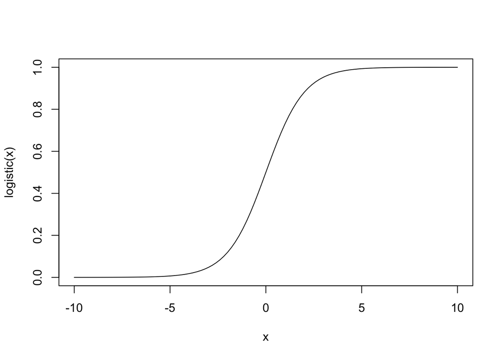

```r
logistic <- function(x) {
  1/(1+exp(-x))
}

curve(logistic(x), from=-10, to=10)
```

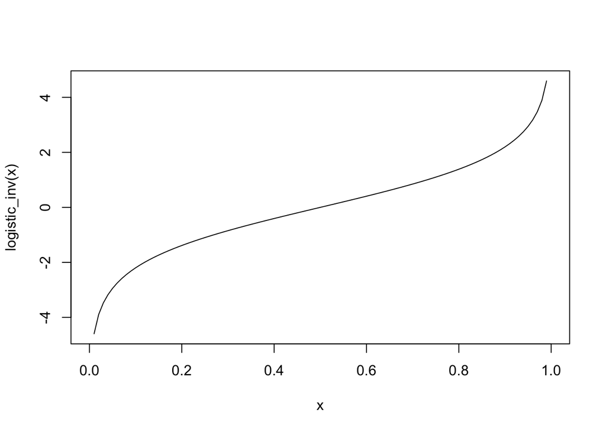

```r
logistic_inv <- function(y) {
  -log((1/y)-1)
}

curve(logistic_inv(x), from=0, to=1)
```

**NOTE“** These functions are quite handy, in evaluating logistic regression results. You may want to save these functions in your own package.

```r
# DO NOT EDIT
c(-Inf,0,Inf) %>% logistic
```

```
## [1] 0.0 0.5 1.0
```

```r
c(0,0.5,1) %>% logistic_inv
```

```
## [1] -Inf    0  Inf
```

## German Credit Model

Using the GermanCredit data from the **Caret** package/ UCI Machine Learning Library, create a model for `Class` (“Good” vs. “Bad” ). Show your model performance.

```r
#install.package("caret")
library(caret)
data("GermanCredit")

# use glm (?glm) -- takes the same formula

#generalize linear models
fit.glm <- glm (Class ~ 1, data = GermanCredit, family="binomial") #glm (class ~.)

stepAIC (fit.glm, scope = ~1 , direction = "forward")
```

```
## Start:  AIC=1223.73
## Class ~ 1
```

```
##
## Call:  glm(formula = Class ~ 1, family = "binomial", data = GermanCredit)
##
## Coefficients:
## (Intercept)
##      0.8473
##
## Degrees of Freedom: 999 Total (i.e. Null);  999 Residual
## Null Deviance:       1222
## Residual Deviance: 1222  AIC: 1224
```

## Iterative Correlated Feature Removal

- Implement Kuhn’s iterative feature removal function described in **APM** Section 3.5, page 47

```r
correlatedFeatureRemoval <- function(x, y){
  rfe(x, y)
}
```

## Synthetic Data (Optional)

- x1: a normally distributed variable with `mean = 20` and standard deviation = 20 (`sd=8`).
- x2: a log-normally distributed feature with `meanlog = 1`, `sdlog=1.2`
- x3: a uniformly distributed feature with `min=0` and `max=50`.

```r
nsamples = 20

x1 <- rnorm(nsamples,20,20)
x2 <- rlnorm(nsamples, meanlog=1, sdlog = 1.2)
x3 <- runif(nsamples,0,50)
```

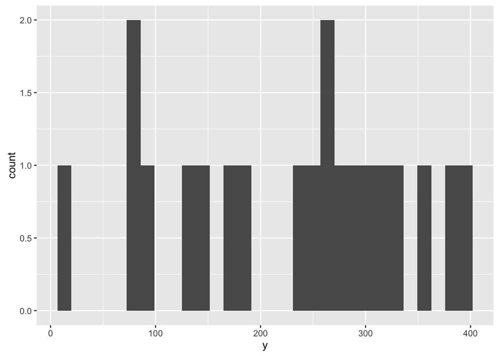

```r
beta0 <- rnorm(nsamples,0,15)  # intercept!
beta1 <- 2.3
beta2 <- 4
beta3 <- 7

betas <- matrix( c(2.5, 4, 7), nrow=1  )  # 1x4 matrix

# x0 <- rep(1,nsamples)

X  <- cbind(x1,x2,x3)  # 1000x4

y <- betas %*% t(X) %>% t
y <- y + beta0

qplot(y)
```

```r
dat <- data.frame(y,X)

fit <- lm( y ~ . , dat )

coef(fit)
```

```
## (Intercept)          x1          x2          x3
##    7.399501    2.665184    4.202086    6.680444
```

```r
fit
```

```
##
## Call:
## lm(formula = y ~ ., data = dat)
##
## Coefficients:
## (Intercept)           x1           x2           x3
##       7.400        2.665        4.202        6.680
```

- Did you recover the betas?
- Is the model good?
- What happens if increase the value of `nsamples`? Decrease it?
- What transformations would you apply to x1? x2? x3?